# Attempt 2 - Logistic Regression

## Partial Feature Engineering with WoE

Using optbinning pip package to do automatic WoE binning and IV analysis instead of writing boilerplate code from scratch

```python
%matplotlib inline
import matplotlib.pyplot as plt

import warnings
warnings.simplefilter(action='ignore', category=FutureWarning)

import pandas as pd

from src.data.utils import read_df, get_xy
from src.nb_utils.data import summarize_df
from src.nb_utils.eval import plot_roc, plot_pr
from src.nb_utils.woe import summarize_woe_iv
from src.data.transforms.woe_transform import forced_binning, WoETransform, WoETransformV2
from src.models.fit import kfold_fit, df_train_test_stratify_split, fit_and_eval
from src.models.ensemble import Ensemble
from src.models.models import StatsModelsLogisticRegression
from src.utils.eval import generate_test_output
```

## Read Data

```python
raw_df = read_df("./data/dataset/cs-training.csv")
summarize_df(raw_df)
```

| Variable Name | N/A count | N/A fraction |
| --- | --- | --- |
| MonthlyIncome | 29731 | 0.198207 |
| NumberOfDependents | 3924 | 0.026160 |
| SeriousDlqin2yrs | 0 | 0.000000 |
| RevolvingUtilizationOfUnsecuredLines | 0 | 0.000000 |
| age | 0 | 0.000000 |
| NumberOfTime30-59DaysPastDueNotWorse | 0 | 0.000000 |
| DebtRatio | 0 | 0.000000 |
| NumberRealEstateLoansOrLines | 0 | 0.000000 |
| NumberOfOpenCreditLinesAndLoans | 0 | 0.000000 |
| NumberOfTimes90DaysLate | 0 | 0.000000 |
| id | 0 | 0.000000 |
| NumberOfTime60-89DaysPastDueNotWorse | 0 | 0.000000 |

## Use auto-binning feature of optbinning

To inspect variable's correlation w. r. t. target variable We can observe some consistent indication with the varabile coefficients from Attempt 1 - e.g. Past Due and unsecured utilizations have very high IVs indicating strong predictors of delinquency, and that some of the negative coefficients (e.g. age, income) corrspond to increasing WoE per orderd bin

```
age
```

|  | Bin | Count | Count (%) | Non-event | Event | Event rate | WoE | IV | JS |
| --- | --- | --- | --- | --- | --- | --- | --- | --- | --- |
| 0 | (-inf, 29.50) | 8821 | 0.058807 | 7786 | 1035 | 0.117334 | -0.618349 | 0.029438 | 0.003622 |
| 1 | [29.50, 36.50) | 15044 | 0.100293 | 13451 | 1593 | 0.105889 | -0.502841 | 0.031574 | 0.003906 |
| 2 | [36.50, 43.50) | 20644 | 0.137627 | 18779 | 1865 | 0.090341 | -0.326797 | 0.016946 | 0.002109 |
| 3 | [43.50, 47.50) | 14229 | 0.094860 | 13073 | 1156 | 0.081243 | -0.210692 | 0.004615 | 0.000576 |
| 4 | [47.50, 49.50) | 7643 | 0.050953 | 7044 | 599 | 0.078372 | -0.171605 | 0.001617 | 0.000202 |
| 5 | [49.50, 52.50) | 10989 | 0.073260 | 10160 | 829 | 0.075439 | -0.130281 | 0.001316 | 0.000164 |
| 6 | [52.50, 55.50) | 10625 | 0.070833 | 9897 | 728 | 0.068518 | -0.026589 | 0.000051 | 0.000006 |
| 7 | [55.50, 59.50) | 13687 | 0.091247 | 12966 | 721 | 0.052678 | 0.253172 | 0.005245 | 0.000654 |
| 8 | [59.50, 62.50) | 10348 | 0.068987 | 9860 | 488 | 0.047159 | 0.369651 | 0.008047 | 0.001000 |
| 9 | [62.50, 67.50) | 14368 | 0.095787 | 13887 | 481 | 0.033477 | 0.726566 | 0.037226 | 0.004554 |
| 10 | [67.50, 74.50) | 12232 | 0.081547 | 11930 | 302 | 0.024689 | 1.04011 | 0.057319 | 0.006858 |
| 11 | [74.50, inf) | 11370 | 0.075800 | 11141 | 229 | 0.020141 | 1.24839 | 0.070850 | 0.008322 |
| 12 | Special | 0 | 0.000000 | 0 | 0 | 0.000000 | 0.0 | 0.000000 | 0.000000 |
| 13 | Missing | 0 | 0.000000 | 0 | 0 | 0.000000 | 0.0 | 0.000000 | 0.000000 |
| Totals |  | 150000 | 1.000000 | 139974 | 10026 | 0.066840 |  | 0.264243 | 0.031974 |

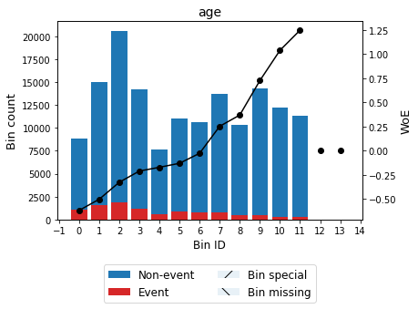

```
DebtRatio
```

|  | Bin | Count | Count (%) | Non-event | Event | Event rate | WoE | IV | JS |
| --- | --- | --- | --- | --- | --- | --- | --- | --- | --- |
| 0 | (-inf, 0.02) | 13043 | 0.086953 | 12384 | 659 | 0.050525 | 0.297162 | 0.006759 | 0.000842 |
| 1 | [0.02, 0.35) | 58248 | 0.388320 | 54765 | 3483 | 0.059796 | 0.118882 | 0.005214 | 0.000651 |
| 2 | [0.35, 0.42) | 12807 | 0.085380 | 11996 | 811 | 0.063325 | 0.057786 | 0.000278 | 0.000035 |
| 3 | [0.42, 0.51) | 10183 | 0.067887 | 9444 | 739 | 0.072572 | -0.088438 | 0.000552 | 0.000069 |
| 4 | [0.51, 0.65) | 10998 | 0.073320 | 10009 | 989 | 0.089925 | -0.321729 | 0.008731 | 0.001087 |
| 5 | [0.65, 3.97) | 14652 | 0.097680 | 12965 | 1687 | 0.115138 | -0.596973 | 0.045154 | 0.005562 |
| 6 | [3.97, 995.50) | 13144 | 0.087627 | 12316 | 828 | 0.062995 | 0.063366 | 0.000342 | 0.000043 |
| 7 | [995.50, inf) | 16925 | 0.112833 | 16095 | 830 | 0.049040 | 0.328563 | 0.010580 | 0.001317 |
| 8 | Special | 0 | 0.000000 | 0 | 0 | 0.000000 | 0.0 | 0.000000 | 0.000000 |
| 9 | Missing | 0 | 0.000000 | 0 | 0 | 0.000000 | 0.0 | 0.000000 | 0.000000 |
| Totals |  | 150000 | 1.000000 | 139974 | 10026 | 0.066840 |  | 0.077609 | 0.009605 |

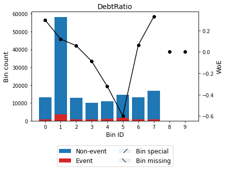

```
NumberOfDependents
```

|  | Bin | Count | Count (%) | Non-event | Event | Event rate | WoE | IV | JS |
| --- | --- | --- | --- | --- | --- | --- | --- | --- | --- |
| 0 | (-inf, 0.50) | 86902 | 0.579347 | 81807 | 5095 | 0.058629 | 0.139828 | 0.010664 | 0.001332 |
| 1 | [0.50, 1.50) | 26316 | 0.175440 | 24381 | 1935 | 0.073529 | -0.102578 | 0.001930 | 0.000241 |
| 2 | [1.50, 2.50) | 19522 | 0.130147 | 17938 | 1584 | 0.081139 | -0.209307 | 0.006245 | 0.000779 |
| 3 | [2.50, inf) | 13336 | 0.088907 | 12103 | 1233 | 0.092457 | -0.352272 | 0.012863 | 0.001600 |
| 4 | Special | 0 | 0.000000 | 0 | 0 | 0.000000 | 0.0 | 0.000000 | 0.000000 |
| 5 | Missing | 3924 | 0.026160 | 3745 | 179 | 0.045617 | 0.404516 | 0.003601 | 0.000447 |
| Totals |  | 150000 | 1.000000 | 139974 | 10026 | 0.066840 |  | 0.035303 | 0.004399 |

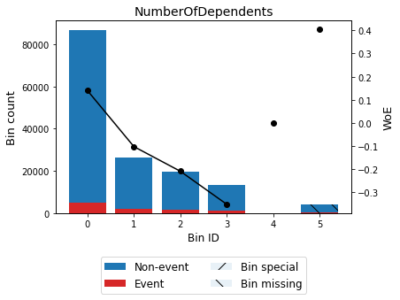

```
RevolvingUtilizationOfUnsecuredLines
```

|  | Bin | Count | Count (%) | Non-event | Event | Event rate | WoE | IV | JS |
| --- | --- | --- | --- | --- | --- | --- | --- | --- | --- |
| 0 | (-inf, 0.06) | 52081 | 0.347207 | 51173 | 908 | 0.017434 | 1.395448 | 0.383783 | 0.044424 |
| 1 | [0.06, 0.13) | 18962 | 0.126413 | 18560 | 402 | 0.021200 | 1.196037 | 0.110634 | 0.013060 |
| 2 | [0.13, 0.22) | 12911 | 0.086073 | 12509 | 402 | 0.031136 | 0.801477 | 0.039489 | 0.004808 |
| 3 | [0.22, 0.30) | 9027 | 0.060180 | 8676 | 351 | 0.038883 | 0.571255 | 0.015409 | 0.001900 |
| 4 | [0.30, 0.39) | 7769 | 0.051793 | 7364 | 405 | 0.052130 | 0.264197 | 0.003227 | 0.000402 |
| 5 | [0.39, 0.49) | 7611 | 0.050740 | 7122 | 489 | 0.064249 | 0.042306 | 0.000089 | 0.000011 |
| 6 | [0.49, 0.70) | 11599 | 0.077327 | 10499 | 1100 | 0.094836 | -0.380305 | 0.013200 | 0.001640 |
| 7 | [0.70, 0.90) | 10172 | 0.067813 | 8662 | 1510 | 0.148447 | -0.889439 | 0.078916 | 0.009552 |
| 8 | [0.90, inf) | 19868 | 0.132453 | 15409 | 4459 | 0.224431 | -1.396248 | 0.467267 | 0.054083 |
| 9 | Special | 0 | 0.000000 | 0 | 0 | 0.000000 | 0.0 | 0.000000 | 0.000000 |
| 10 | Missing | 0 | 0.000000 | 0 | 0 | 0.000000 | 0.0 | 0.000000 | 0.000000 |
| Totals |  | 150000 | 1.000000 | 139974 | 10026 | 0.066840 |  | 1.112014 | 0.129880 |

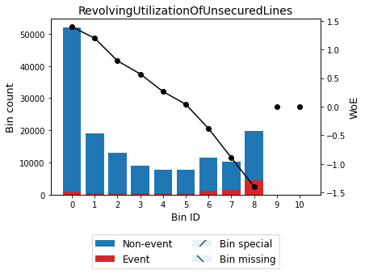

```
NumberOfOpenCreditLinesAndLoans
```

|  | Bin | Count | Count (%) | Non-event | Event | Event rate | WoE | IV | JS |
| --- | --- | --- | --- | --- | --- | --- | --- | --- | --- |
| 0 | (-inf, 2.50) | 12992 | 0.086613 | 11314 | 1678 | 0.129156 | -0.727837 | 0.062984 | 0.007704 |
| 1 | [2.50, 3.50) | 9058 | 0.060387 | 8376 | 682 | 0.075293 | -0.128179 | 0.001049 | 0.000131 |
| 2 | [3.50, 4.50) | 11609 | 0.077393 | 10866 | 743 | 0.064002 | 0.046423 | 0.000163 | 0.000020 |
| 3 | [4.50, 5.50) | 12931 | 0.086207 | 12112 | 819 | 0.063336 | 0.057593 | 0.000279 | 0.000035 |
| 4 | [5.50, 7.50) | 26859 | 0.179060 | 25358 | 1501 | 0.055884 | 0.190688 | 0.005997 | 0.000749 |
| 5 | [7.50, 8.50) | 12562 | 0.083747 | 11956 | 606 | 0.048241 | 0.345834 | 0.008637 | 0.001074 |
| 6 | [8.50, 11.50) | 29300 | 0.195333 | 27591 | 1709 | 0.058328 | 0.145306 | 0.003874 | 0.000484 |
| 7 | [11.50, 13.50) | 12672 | 0.084480 | 11921 | 751 | 0.059265 | 0.128376 | 0.001317 | 0.000165 |
| 8 | [13.50, inf) | 22017 | 0.146780 | 20480 | 1537 | 0.069810 | -0.046659 | 0.000326 | 0.000041 |
| 9 | Special | 0 | 0.000000 | 0 | 0 | 0.000000 | 0.0 | 0.000000 | 0.000000 |
| 10 | Missing | 0 | 0.000000 | 0 | 0 | 0.000000 | 0.0 | 0.000000 | 0.000000 |
| Totals |  | 150000 | 1.000000 | 139974 | 10026 | 0.066840 |  | 0.084626 | 0.010402 |

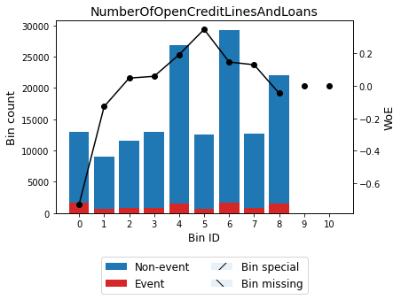

```
NumberOfTime60-89DaysPastDueNotWorse
```

|  | Bin | Count | Count (%) | Non-event | Event | Event rate | WoE | IV | JS |
| --- | --- | --- | --- | --- | --- | --- | --- | --- | --- |
| 0 | (-inf, 0.50) | 142396 | 0.949307 | 135140 | 7256 | 0.050956 | 0.288208 | 0.069673 | 0.008679 |
| 1 | [0.50, inf) | 7604 | 0.050693 | 4834 | 2770 | 0.364282 | -2.079448 | 0.502700 | 0.053510 |
| 2 | Special | 0 | 0.000000 | 0 | 0 | 0.000000 | 0.0 | 0.000000 | 0.000000 |
| 3 | Missing | 0 | 0.000000 | 0 | 0 | 0.000000 | 0.0 | 0.000000 | 0.000000 |
| Totals |  | 150000 | 1.000000 | 139974 | 10026 | 0.066840 |  | 0.572373 | 0.062189 |

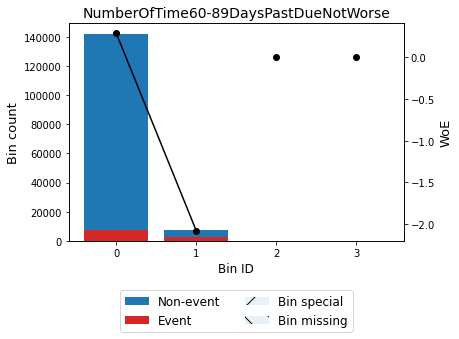

```
MonthlyIncome
```

|  | Bin | Count | Count (%) | Non-event | Event | Event rate | WoE | IV | JS |
| --- | --- | --- | --- | --- | --- | --- | --- | --- | --- |
| 0 | (-inf, 1508.50) | 7640 | 0.050933 | 7080 | 560 | 0.073298 | -0.099183 | 5.230844e-04 | 6.535877e-05 |
| 1 | [1508.50, 2569.50) | 10929 | 0.072860 | 9879 | 1050 | 0.096075 | -0.394654 | 1.347755e-02 | 1.673845e-03 |
| 2 | [2569.50, 3459.50) | 12232 | 0.081547 | 11006 | 1226 | 0.100229 | -0.441591 | 1.927686e-02 | 2.390218e-03 |
| 3 | [3459.50, 4831.50) | 20911 | 0.139407 | 19191 | 1720 | 0.082253 | -0.224158 | 7.722221e-03 | 9.632618e-04 |
| 4 | [4831.50, 5320.50) | 7611 | 0.050740 | 7068 | 543 | 0.071344 | -0.070051 | 2.566751e-04 | 3.207783e-05 |
| 5 | [5320.50, 6643.50) | 16128 | 0.107520 | 15050 | 1078 | 0.066840 | -0.000004 | 2.132545e-12 | 2.665742e-13 |
| 6 | [6643.50, 7656.50) | 9903 | 0.066020 | 9353 | 550 | 0.055539 | 0.197259 | 2.359650e-03 | 2.944790e-04 |
| 7 | [7656.50, 9945.50) | 14975 | 0.099833 | 14207 | 768 | 0.051285 | 0.281425 | 7.006530e-03 | 8.729375e-04 |
| 8 | [9945.50, inf) | 19940 | 0.132933 | 19078 | 862 | 0.043230 | 0.460761 | 2.318562e-02 | 2.872834e-03 |
| 9 | Special | 0 | 0.000000 | 0 | 0 | 0.000000 | 0.0 | 0.000000e+00 | 0.000000e+00 |
| 10 | Missing | 29731 | 0.198207 | 28062 | 1669 | 0.056137 | 0.185917 | 6.323568e-03 | 7.893095e-04 |
| Totals |  | 150000 | 1.000000 | 139974 | 10026 | 0.066840 |  | 8.013176e-02 | 9.954322e-03 |

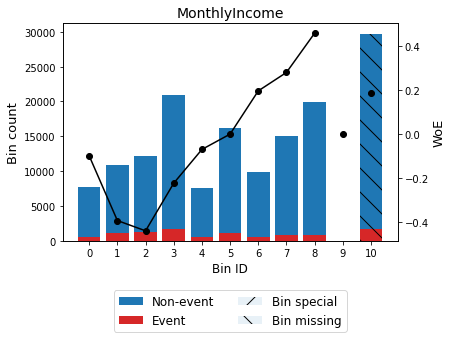

```
NumberOfTimes90DaysLate
```

|  | Bin | Count | Count (%) | Non-event | Event | Event rate | WoE | IV | JS |
| --- | --- | --- | --- | --- | --- | --- | --- | --- | --- |
| 0 | (-inf, 0.50) | 141662 | 0.944413 | 135108 | 6554 | 0.046265 | 0.389724 | 0.121413 | 0.015081 |
| 1 | [0.50, inf) | 8338 | 0.055587 | 4866 | 3472 | 0.416407 | -2.298734 | 0.716138 | 0.073884 |
| 2 | Special | 0 | 0.000000 | 0 | 0 | 0.000000 | 0.0 | 0.000000 | 0.000000 |
| 3 | Missing | 0 | 0.000000 | 0 | 0 | 0.000000 | 0.0 | 0.000000 | 0.000000 |
| Totals |  | 150000 | 1.000000 | 139974 | 10026 | 0.066840 |  | 0.837551 | 0.088965 |

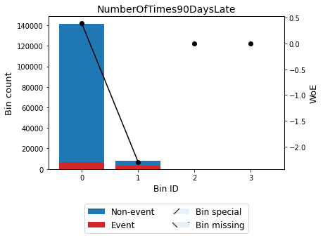

```
NumberOfTime30-59DaysPastDueNotWorse
```

|  | Bin | Count | Count (%) | Non-event | Event | Event rate | WoE | IV | JS |
| --- | --- | --- | --- | --- | --- | --- | --- | --- | --- |
| 0 | (-inf, 0.50) | 126018 | 0.840120 | 120977 | 5041 | 0.040002 | 0.541721 | 0.195826 | 0.024183 |
| 1 | [0.50, 1.50) | 16033 | 0.106887 | 13624 | 2409 | 0.150253 | -0.903654 | 0.129171 | 0.015618 |
| 2 | [1.50, inf) | 7949 | 0.052993 | 5373 | 2576 | 0.324066 | -1.901126 | 0.415484 | 0.045301 |
| 3 | Special | 0 | 0.000000 | 0 | 0 | 0.000000 | 0.0 | 0.000000 | 0.000000 |
| 4 | Missing | 0 | 0.000000 | 0 | 0 | 0.000000 | 0.0 | 0.000000 | 0.000000 |
| Totals |  | 150000 | 1.000000 | 139974 | 10026 | 0.066840 |  | 0.740481 | 0.085103 |

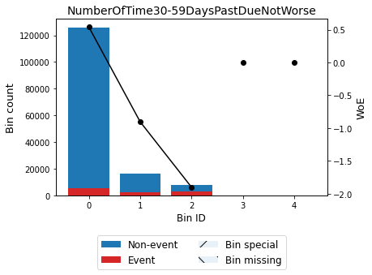

```
NumberRealEstateLoansOrLines
```

|  | Bin | Count | Count (%) | Non-event | Event | Event rate | WoE | IV | JS |
| --- | --- | --- | --- | --- | --- | --- | --- | --- | --- |
| 0 | (-inf, 0.50) | 56188 | 0.374587 | 51516 | 4672 | 0.083149 | -0.23597 | 0.023113 | 0.002882 |
| 1 | [0.50, 1.50) | 52338 | 0.348920 | 49590 | 2748 | 0.052505 | 0.256641 | 0.020581 | 0.002566 |
| 2 | [1.50, 2.50) | 31522 | 0.210147 | 29757 | 1765 | 0.055993 | 0.188639 | 0.006894 | 0.000861 |
| 3 | [2.50, inf) | 9952 | 0.066347 | 9111 | 841 | 0.084506 | -0.253629 | 0.004766 | 0.000594 |
| 4 | Special | 0 | 0.000000 | 0 | 0 | 0.000000 | 0.0 | 0.000000 | 0.000000 |
| 5 | Missing | 0 | 0.000000 | 0 | 0 | 0.000000 | 0.0 | 0.000000 | 0.000000 |
| Totals |  | 150000 | 1.000000 | 139974 | 10026 | 0.066840 |  | 0.055354 | 0.006903 |

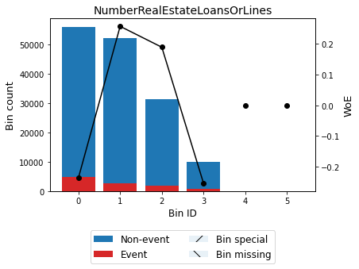

```python
splits = summarize_woe_iv(raw_df, 'id', 'SeriousDlqin2yrs')
```

## Select several continuous variables that we can bin nicely and redo

Monotonic bins w. r. t. WoE. Also, we will include the 2 variables with missing data NumberOfDependents and MonthlyIncome so we man map 'N/A' class to a WoE value for logistic regression

```
x=NumberOfDependents, y=SeriousDlqin2yrs
```

|  | Bin | Count | Count (%) | Non-event | Event | Event rate | WoE | IV | JS |
| --- | --- | --- | --- | --- | --- | --- | --- | --- | --- |
| 0 | (-inf, 0.50) | 86902 | 0.579347 | 81807 | 5095 | 0.058629 | 0.139828 | 0.010664 | 0.001332 |
| 1 | [0.50, 1.50) | 26316 | 0.175440 | 24381 | 1935 | 0.073529 | -0.102578 | 0.001930 | 0.000241 |
| 2 | [1.50, 2.50) | 19522 | 0.130147 | 17938 | 1584 | 0.081139 | -0.209307 | 0.006245 | 0.000779 |
| 3 | [2.50, inf) | 13336 | 0.088907 | 12103 | 1233 | 0.092457 | -0.352272 | 0.012863 | 0.001600 |
| 4 | Special | 0 | 0.000000 | 0 | 0 | 0.000000 | 0.0 | 0.000000 | 0.000000 |
| 5 | Missing | 3924 | 0.026160 | 3745 | 179 | 0.045617 | 0.404516 | 0.003601 | 0.000447 |
| Totals |  | 150000 | 1.000000 | 139974 | 10026 | 0.066840 |  | 0.035303 | 0.004399 |

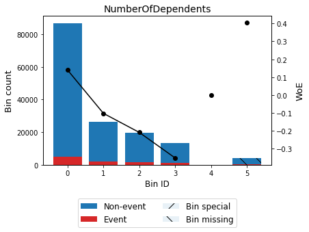

```python
NumberOfDependentsBins = forced_binning(raw_df, 'NumberOfDependents', 'SeriousDlqin2yrs', 'ascending', 0)
```

```
x=DebtRatio, y=SeriousDlqin2yrs
```

|  | Bin | Count | Count (%) | Non-event | Event | Event rate | WoE | IV | JS |
| --- | --- | --- | --- | --- | --- | --- | --- | --- | --- |
| 0 | (-inf, 0.02) | 13043 | 0.086953 | 12384 | 659 | 0.050525 | 0.297162 | 0.006759 | 0.000842 |
| 1 | [0.02, 0.35) | 58248 | 0.388320 | 54765 | 3483 | 0.059796 | 0.118882 | 0.005214 | 0.000651 |
| 2 | [0.35, 0.42) | 12807 | 0.085380 | 11996 | 811 | 0.063325 | 0.057786 | 0.000278 | 0.000035 |
| 3 | [0.42, 0.51) | 10183 | 0.067887 | 9444 | 739 | 0.072572 | -0.088438 | 0.000552 | 0.000069 |
| 4 | [0.51, inf) | 55719 | 0.371460 | 51385 | 4334 | 0.077783 | -0.16342 | 0.010650 | 0.001330 |
| 5 | Special | 0 | 0.000000 | 0 | 0 | 0.000000 | 0.0 | 0.000000 | 0.000000 |
| 6 | Missing | 0 | 0.000000 | 0 | 0 | 0.000000 | 0.0 | 0.000000 | 0.000000 |
| Totals |  | 150000 | 1.000000 | 139974 | 10026 | 0.066840 |  | 0.023453 | 0.002927 |

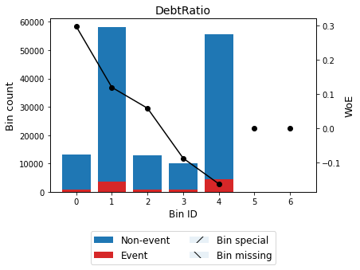

```python
DebtRatioBins = forced_binning(raw_df, 'DebtRatio', 'SeriousDlqin2yrs', 'ascending', 0)
```

```
x=MonthlyIncome, y=SeriousDlqin2yrs
```

|  | Bin | Count | Count (%) | Non-event | Event | Event rate | WoE | IV | JS |
| --- | --- | --- | --- | --- | --- | --- | --- | --- | --- |
| 0 | (-inf, 3459.50) | 30801 | 0.205340 | 27965 | 2836 | 0.092075 | -0.347716 | 2.888735e-02 | 3.592837e-03 |
| 1 | [3459.50, 4831.50) | 20911 | 0.139407 | 19191 | 1720 | 0.082253 | -0.224158 | 7.722221e-03 | 9.632618e-04 |
| 2 | [4831.50, 5320.50) | 7611 | 0.050740 | 7068 | 543 | 0.071344 | -0.070051 | 2.566751e-04 | 3.207783e-05 |
| 3 | [5320.50, 6643.50) | 16128 | 0.107520 | 15050 | 1078 | 0.066840 | -0.000004 | 2.132545e-12 | 2.665742e-13 |
| 4 | [6643.50, 7656.50) | 9903 | 0.066020 | 9353 | 550 | 0.055539 | 0.197259 | 2.359650e-03 | 2.944790e-04 |
| 5 | [7656.50, 9945.50) | 14975 | 0.099833 | 14207 | 768 | 0.051285 | 0.281425 | 7.006530e-03 | 8.729375e-04 |
| 6 | [9945.50, inf) | 19940 | 0.132933 | 19078 | 862 | 0.043230 | 0.460761 | 2.318562e-02 | 2.872834e-03 |
| 7 | Special | 0 | 0.000000 | 0 | 0 | 0.000000 | 0.0 | 0.000000e+00 | 0.000000e+00 |
| 8 | Missing | 29731 | 0.198207 | 28062 | 1669 | 0.056137 | 0.185917 | 6.323568e-03 | 7.893095e-04 |
| Totals |  | 150000 | 1.000000 | 139974 | 10026 | 0.066840 |  | 7.574161e-02 | 9.417736e-03 |

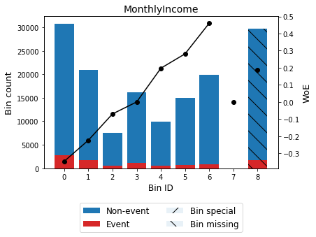

```python
MonthlyIncomeBins = forced_binning(raw_df, 'MonthlyIncome', 'SeriousDlqin2yrs', 'descending', 0)
```

```
x=age, y=SeriousDlqin2yrs
```

|  | Bin | Count | Count (%) | Non-event | Event | Event rate | WoE | IV | JS |
| --- | --- | --- | --- | --- | --- | --- | --- | --- | --- |
| 0 | (-inf, 29.50) | 8821 | 0.058807 | 7786 | 1035 | 0.117334 | -0.618349 | 0.029438 | 0.003622 |
| 1 | [29.50, 36.50) | 15044 | 0.100293 | 13451 | 1593 | 0.105889 | -0.502841 | 0.031574 | 0.003906 |
| 2 | [36.50, 43.50) | 20644 | 0.137627 | 18779 | 1865 | 0.090341 | -0.326797 | 0.016946 | 0.002109 |
| 3 | [43.50, 47.50) | 14229 | 0.094860 | 13073 | 1156 | 0.081243 | -0.210692 | 0.004615 | 0.000576 |
| 4 | [47.50, 52.50) | 18632 | 0.124213 | 17204 | 1428 | 0.076642 | -0.147408 | 0.002878 | 0.000359 |
| 5 | [52.50, 55.50) | 10625 | 0.070833 | 9897 | 728 | 0.068518 | -0.026589 | 0.000051 | 0.000006 |
| 6 | [55.50, 59.50) | 13687 | 0.091247 | 12966 | 721 | 0.052678 | 0.253172 | 0.005245 | 0.000654 |
| 7 | [59.50, 62.50) | 10348 | 0.068987 | 9860 | 488 | 0.047159 | 0.369651 | 0.008047 | 0.001000 |
| 8 | [62.50, 67.50) | 14368 | 0.095787 | 13887 | 481 | 0.033477 | 0.726566 | 0.037226 | 0.004554 |
| 9 | [67.50, 74.50) | 12232 | 0.081547 | 11930 | 302 | 0.024689 | 1.04011 | 0.057319 | 0.006858 |
| 10 | [74.50, inf) | 11370 | 0.075800 | 11141 | 229 | 0.020141 | 1.24839 | 0.070850 | 0.008322 |
| 11 | Special | 0 | 0.000000 | 0 | 0 | 0.000000 | 0.0 | 0.000000 | 0.000000 |
| 12 | Missing | 0 | 0.000000 | 0 | 0 | 0.000000 | 0.0 | 0.000000 | 0.000000 |
| Totals |  | 150000 | 1.000000 | 139974 | 10026 | 0.066840 |  | 0.264188 | 0.031967 |

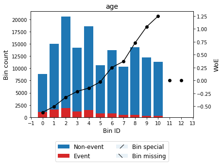

```python
ageBins = forced_binning(raw_df, 'age', 'SeriousDlqin2yrs', 'descending', 0.1)
```

```
x=RevolvingUtilizationOfUnsecuredLines, y=SeriousDlqin2yrs
```

|  | Bin | Count | Count (%) | Non-event | Event | Event rate | WoE | IV | JS |
| --- | --- | --- | --- | --- | --- | --- | --- | --- | --- |
| 0 | (-inf, 0.06) | 52081 | 0.347207 | 51173 | 908 | 0.017434 | 1.395448 | 0.383783 | 0.044424 |
| 1 | [0.06, 0.13) | 18962 | 0.126413 | 18560 | 402 | 0.021200 | 1.196037 | 0.110634 | 0.013060 |
| 2 | [0.13, 0.30) | 21938 | 0.146253 | 21185 | 753 | 0.034324 | 0.700708 | 0.053425 | 0.006545 |
| 3 | [0.30, 0.49) | 15380 | 0.102533 | 14486 | 894 | 0.058127 | 0.148957 | 0.002133 | 0.000266 |
| 4 | [0.49, 0.70) | 11599 | 0.077327 | 10499 | 1100 | 0.094836 | -0.380305 | 0.013200 | 0.001640 |
| 5 | [0.70, 0.90) | 10172 | 0.067813 | 8662 | 1510 | 0.148447 | -0.889439 | 0.078916 | 0.009552 |
| 6 | [0.90, inf) | 19868 | 0.132453 | 15409 | 4459 | 0.224431 | -1.396248 | 0.467267 | 0.054083 |
| 7 | Special | 0 | 0.000000 | 0 | 0 | 0.000000 | 0.0 | 0.000000 | 0.000000 |
| 8 | Missing | 0 | 0.000000 | 0 | 0 | 0.000000 | 0.0 | 0.000000 | 0.000000 |
| Totals |  | 150000 | 1.000000 | 139974 | 10026 | 0.066840 |  | 1.109358 | 0.129570 |

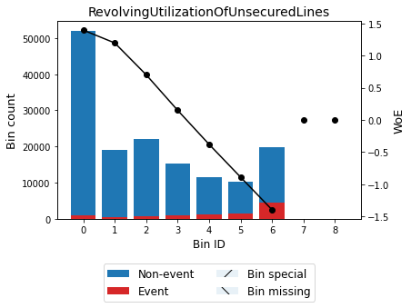

```python
RevolvingUtilizationOfUnsecuredLinesBin = forced_binning(raw_df, 'RevolvingUtilizationOfUnsecuredLines', 'SeriousDlqin2yrs', 'ascending', 0.2)
```

```
x=NumberOfOpenCreditLinesAndLoans, y=SeriousDlqin2yrs
```

|  | Bin | Count | Count (%) | Non-event | Event | Event rate | WoE | IV | JS |
| --- | --- | --- | --- | --- | --- | --- | --- | --- | --- |
| 0 | (-inf, 2.50) | 12992 | 0.086613 | 11314 | 1678 | 0.129156 | -0.727837 | 0.062984 | 0.007704 |
| 1 | [2.50, 3.50) | 9058 | 0.060387 | 8376 | 682 | 0.075293 | -0.128179 | 0.001049 | 0.000131 |
| 2 | [3.50, 4.50) | 11609 | 0.077393 | 10866 | 743 | 0.064002 | 0.046423 | 0.000163 | 0.000020 |
| 3 | [4.50, 5.50) | 12931 | 0.086207 | 12112 | 819 | 0.063336 | 0.057593 | 0.000279 | 0.000035 |
| 4 | [5.50, inf) | 103410 | 0.689400 | 97306 | 6104 | 0.059027 | 0.132641 | 0.011454 | 0.001431 |
| 5 | Special | 0 | 0.000000 | 0 | 0 | 0.000000 | 0.0 | 0.000000 | 0.000000 |
| 6 | Missing | 0 | 0.000000 | 0 | 0 | 0.000000 | 0.0 | 0.000000 | 0.000000 |
| Totals |  | 150000 | 1.000000 | 139974 | 10026 | 0.066840 |  | 0.075929 | 0.009321 |

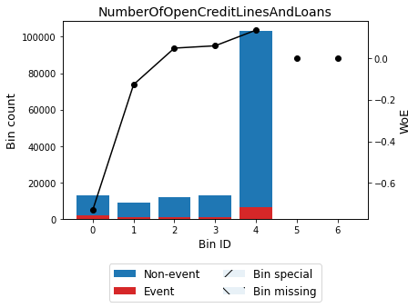

```python
NumberOfOpenCreditLinesAndLoansBin = forced_binning(raw_df, 'NumberOfOpenCreditLinesAndLoans', 'SeriousDlqin2yrs', 'descending', 0)
```

```
x=NumberRealEstateLoansOrLines, y=SeriousDlqin2yrs
```

|  | Bin | Count | Count (%) | Non-event | Event | Event rate | WoE | IV | JS |
| --- | --- | --- | --- | --- | --- | --- | --- | --- | --- |
| 0 | (-inf, 1.00) | 56188 | 0.374587 | 51516 | 4672 | 0.083149 | -0.23597 | 0.023113 | 0.002882 |
| 1 | [1.00, 2.00) | 52338 | 0.348920 | 49590 | 2748 | 0.052505 | 0.256641 | 0.020581 | 0.002566 |
| 2 | [2.00, 3.00) | 31522 | 0.210147 | 29757 | 1765 | 0.055993 | 0.188639 | 0.006894 | 0.000861 |
| 3 | [3.00, inf) | 9952 | 0.066347 | 9111 | 841 | 0.084506 | -0.253629 | 0.004766 | 0.000594 |
| 4 | Special | 0 | 0.000000 | 0 | 0 | 0.000000 | 0.0 | 0.000000 | 0.000000 |
| 5 | Missing | 0 | 0.000000 | 0 | 0 | 0.000000 | 0.0 | 0.000000 | 0.000000 |
| Totals |  | 150000 | 1.000000 | 139974 | 10026 | 0.066840 |  | 0.055354 | 0.006903 |

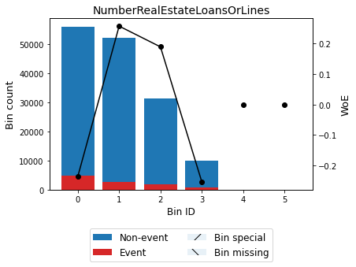

```python
NumberRealEstateLoansOrLinesBin = forced_binning(
    raw_df, 'NumberRealEstateLoansOrLines', 'SeriousDlqin2yrs', None, 0, user_splits=[1, 2, 3])
```

```
x=NumberOfTime30-59DaysPastDueNotWorse, y=SeriousDlqin2yrs
```

|  | Bin | Count | Count (%) | Non-event | Event | Event rate | WoE | IV | JS |
| --- | --- | --- | --- | --- | --- | --- | --- | --- | --- |
| 0 | (-inf, 1.00) | 126018 | 0.840120 | 120977 | 5041 | 0.040002 | 0.541721 | 0.195826 | 0.024183 |
| 1 | [1.00, 2.00) | 16033 | 0.106887 | 13624 | 2409 | 0.150253 | -0.903654 | 0.129171 | 0.015618 |
| 2 | [2.00, inf) | 7949 | 0.052993 | 5373 | 2576 | 0.324066 | -1.901126 | 0.415484 | 0.045301 |
| 3 | Special | 0 | 0.000000 | 0 | 0 | 0.000000 | 0.0 | 0.000000 | 0.000000 |
| 4 | Missing | 0 | 0.000000 | 0 | 0 | 0.000000 | 0.0 | 0.000000 | 0.000000 |
| Totals |  | 150000 | 1.000000 | 139974 | 10026 | 0.066840 |  | 0.740481 | 0.085103 |

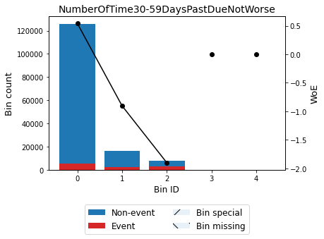

```python
NumberOfTime3059DaysPastDueNotWorse = forced_binning(
    raw_df, 'NumberOfTime30-59DaysPastDueNotWorse', 'SeriousDlqin2yrs', None, 0, user_splits=[0, 1, 2])
```

## Define final transformations

Map bins to their WoE values

1. WoETransform - will drop highly-correlated variables as before. However, manual checking reveals that NumberOfTimes90DaysLate is a lot more bunched up than NumberOfTime30-59DaysPastDueNotWorse (>94% are 0-value vs ~84% for the latter) - so we will drop NumberOfTimes90DaysLate instead
2. WoETransformV2 - won't drop any of the correlated past due and late count variables as Attempt 1 shows that it is boosts performance

```python
transform_df_woe = WoETransform()
transform_df_woe.woe_fit(raw_df)

transform_df_woe_v2 = WoETransformV2()
transform_df_woe_v2.woe_fit(raw_df)
transform_df_woe_v2.save("./data/models/woe_fit_v2.pckl")
```

```
Saved to ./data/models/woe_fit_v2.pckl
```

```python
df_woe, _ = transform_df_woe(raw_df)
df_woe

transform_df_woe_v2 = WoETransformV2()
transform_df_woe_v2.load("./data/models/woe_fit_v2.pckl")

df_woe_v2, _ = transform_df_woe_v2(raw_df)
df_woe_v2
```

|  | id | SeriousDlqin2yrs | RevolvingUtilizationOfUnsecuredLines | age | NumberOfTime30-59DaysPastDueNotWorse | DebtRatio | MonthlyIncome | NumberOfOpenCreditLinesAndLoans | NumberOfTimes90DaysLate | NumberRealEstateLoansOrLines | NumberOfTime60-89DaysPastDueNotWorse | NumberOfDependents |
| --- | --- | --- | --- | --- | --- | --- | --- | --- | --- | --- | --- | --- |
| 0 | 1 | 1 | -0.889439 | -0.210692 | -1.901126 | -0.163420 | 0.281425 | 0.132641 | 0.389724 | -0.253629 | 0.288208 | -0.209307 |
| 1 | 2 | 0 | -1.396248 | -0.326797 | 0.541721 | 0.118882 | -0.347716 | 0.046423 | 0.389724 | -0.235970 | 0.288208 | -0.102578 |
| 2 | 3 | 0 | -0.380305 | -0.326797 | -0.903654 | 0.118882 | -0.347716 | -0.727837 | -1.957968 | -0.235970 | 0.288208 | 0.139828 |
| 3 | 4 | 0 | 0.700708 | -0.502841 | 0.541721 | 0.118882 | -0.347716 | 0.057593 | 0.389724 | -0.235970 | 0.288208 | 0.139828 |
| 4 | 5 | 0 | -1.396248 | -0.147408 | -0.903654 | 0.118882 | 0.460761 | 0.132641 | 0.389724 | 0.256641 | 0.288208 | 0.139828 |
| ... | ... | ... | ... | ... | ... | ... | ... | ... | ... | ... | ... | ... |
| 149995 | 149996 | 0 | 1.395448 | 1.040110 | 0.541721 | 0.118882 | -0.347716 | 0.046423 | 0.389724 | 0.256641 | 0.288208 | 0.139828 |
| 149996 | 149997 | 0 | 0.700708 | -0.210692 | 0.541721 | -0.163420 | -0.000004 | 0.046423 | 0.389724 | 0.256641 | 0.288208 | -0.209307 |
| 149997 | 149998 | 0 | 0.700708 | 0.253172 | 0.541721 | -0.163420 | 0.000000 | 0.132641 | 0.389724 | 0.256641 | 0.288208 | 0.139828 |
| 149998 | 149999 | 0 | 1.395448 | -0.502841 | 0.541721 | 0.297162 | -0.000004 | 0.046423 | 0.389724 | -0.235970 | 0.288208 | 0.139828 |
| 149999 | 150000 | 0 | -0.889439 | 0.726566 | 0.541721 | 0.118882 | 0.281425 | 0.132641 | 0.389724 | 0.188639 | 0.288208 | 0.139828 |

150000 rows × 12 columns

## Train Models

1. WoETransform (drop correlated columns) gives slightly better AUC and PR curves compared to Attempt 1 for 'Test 3 - drop columns & log most' i.e. drop the correlated columns and log almost all the variables
2. WoeTransformV2 (don't drop any column) gives similar perfornce compared to Attempt 1 for 'Test 4 - don't drop columns and log most'
3. The caveat here is that we did use all the training data to create the WoE bins, and to train. If we are doing this properly we should have a proper test/train split

```python
print(f"WoE Model")
sm_model_woe = kfold_fit(df_woe, 5, StatsModelsLogisticRegression)
sm_model_woe.save("./data/models/sm_model_woe.pckl")

print(f"WoE v2 Model")
sm_model_woe_v2 = kfold_fit(df_woe_v2, 5, StatsModelsLogisticRegression)
sm_model_woe_v2.save("./data/models/sm_model_woe_v2.pckl")
```

```
WoE Model
kfold x-val for k=5
run 1 - class [0 1] for train=[111980   8020], test=[27994  2006] --> AUC=0.827
run 2 - class [0 1] for train=[111979   8021], test=[27995  2005] --> AUC=0.824
run 3 - class [0 1] for train=[111979   8021], test=[27995  2005] --> AUC=0.835
run 4 - class [0 1] for train=[111979   8021], test=[27995  2005] --> AUC=0.822
run 5 - class [0 1] for train=[111979   8021], test=[27995  2005] --> AUC=0.839
WoE v2 Model
kfold x-val for k=5
run 1 - class [0 1] for train=[111980   8020], test=[27994  2006] --> AUC=0.853
run 2 - class [0 1] for train=[111979   8021], test=[27995  2005] --> AUC=0.862
run 3 - class [0 1] for train=[111979   8021], test=[27995  2005] --> AUC=0.856
run 4 - class [0 1] for train=[111979   8021], test=[27995  2005] --> AUC=0.854
run 5 - class [0 1] for train=[111979   8021], test=[27995  2005] --> AUC=0.859
```

### WoE Transfrom (drop correlated columns)

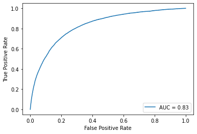

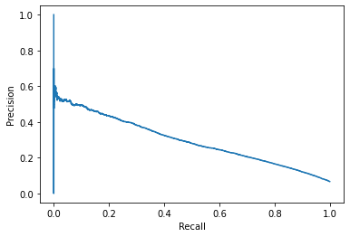

```python
sm_model_woe = StatsModelsLogisticRegression("./data/models/sm_model_woe.pckl")

X, y = get_xy(df_woe)
plot_roc(sm_model_woe, X, y)
plot_pr(sm_model_woe, X, y)
```

### WoE Transfrom V2 (don't drop correlated columns)

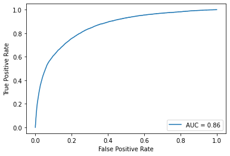

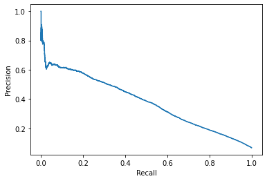

```python
sm_model_woe_v2 = StatsModelsLogisticRegression("./data/models/sm_model_woe_v2.pckl")

X, y = get_xy(df_woe_v2)
plot_roc(sm_model_woe_v2, X, y)
plot_pr(sm_model_woe_v2, X, y)
```

# Choose WoE Transform V2

Because it has the best AUC and we was in Attempt 1 that including all past dues boost results

```python
sm_model_woe_v2 = StatsModelsLogisticRegression("./data/models/sm_model_woe_v2.pckl")
transform_df_woe_v2 = WoETransformV2()
transform_df_woe_v2.load("./data/models/woe_fit_v2.pckl")

model_with_transform = Ensemble()
model_with_transform.add_model(sm_model_woe_v2, weight=1.0, transform=transform_df_woe_v2)

# Kaggle AUC=0.85679
generate_test_output("./data/dataset/cs-test.csv", model_with_transform, './data/outputs/pred_out_woe_v2.csv')
```

|  | id | Probability |
| --- | --- | --- |
| 0 | 1 | 0.504958 |
| 1 | 2 | 0.375456 |
| 2 | 3 | 0.163808 |
| 3 | 4 | 0.498208 |
| 4 | 5 | 0.655796 |
| ... | ... | ... |
| 101498 | 101499 | 0.315635 |
| 101499 | 101500 | 0.893735 |
| 101500 | 101501 | 0.165013 |
| 101501 | 101502 | 0.599273 |
| 101502 | 101503 | 0.380296 |

101503 rows × 2 columns

# Sanity check for proper Train/Test split AUC and PR Curves

```
class [0 1] for train=[97982  7018], test=[41992  3008] - auc=0.852
Train
```

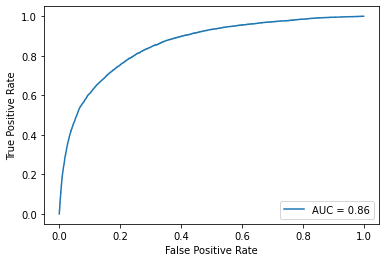

[output not shown]

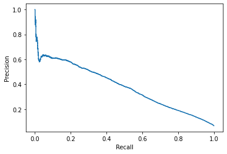

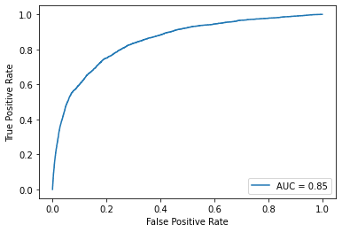

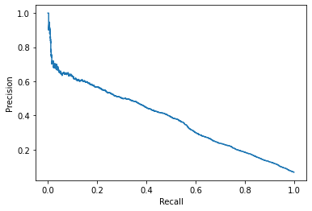

```python
X_train, X_test, y_train, y_test = df_train_test_stratify_split(raw_df, test_size=0.3)
Xy_train_df = pd.concat([X_train, y_train], axis=1)

transform_df_woe_v2 = WoETransformV2()
transform_df_woe_v2.woe_fit(Xy_train_df)

X_woe_train, _ = transform_df_woe_v2(X_train)
X_woe_test, _ = transform_df_woe_v2(X_test)

sm_model_woe_v2_train_test = fit_and_eval(StatsModelsLogisticRegression, X_woe_train, X_woe_test, y_train, y_test)

print("Train")
plot_roc(sm_model_woe_v2_train_test, X_woe_train, y_train)
plot_pr(sm_model_woe_v2_train_test, X_woe_train, y_train)

print("Test")
plot_roc(sm_model_woe_v2_train_test, X_woe_test, y_test)
plot_pr(sm_model_woe_v2_train_test, X_woe_test, y_test)
```